# README

Timothy Nessel

10/8/2018

# BCB546X_R_ASSIGNMENT

## Author: Timothy Nessel

#### Setting the Environment

I will start by loading the required packages if required

```r
if (!require("tidyverse")) install.packages("tidyverse")
```

```r
if (!require("ggplot2")) install.packages("ggplot2")
if (!require("reshape2")) install.packages("reshape2")
if (!require("tidyr")) install.packages("tidyr")
if (!require("plyr")) install.packages("plyr")
library(tidyverse)
library(ggplot2)
library(reshape2)
library(tidyr)
library(plyr)
```

We will also need to load the required files from the class github repository. I specify that there is a header, and that the delimiting character is a tab.

```r
fang_et_al_genotypes <- read.table("https://raw.githubusercontent.com/EEOB-BioData/BCB546X-Fall2018/master/assignments/UNIX_Assignment/fang_et_al_genotypes.txt", header = TRUE, sep = "\t")
snp_position <- read.table("https://raw.githubusercontent.com/EEOB-BioData/BCB546X-Fall2018/master/assignments/UNIX_Assignment/snp_position.txt", header = TRUE, sep = "\t")
```

#### Inspecting the Files

Using the following commands, we can get some information about our two files, their dimensions, structure, column names, and the first 5 rows of the file:

```r
file.info("fang_et_al_genotypes")
```

```
##                      size isdir mode mtime ctime atime uid gid uname
## fang_et_al_genotypes   NA    NA <NA>  <NA>  <NA>  <NA>  NA  NA  <NA>
##                      grname
## fang_et_al_genotypes   <NA>
```

```r
dim(fang_et_al_genotypes)
```

```
## [1] 2782  986
```

```r
str(fang_et_al_genotypes)
```

```
## 'data.frame':    2782 obs. of  986 variables:
##  $ Sample_ID     : Factor w/ 2782 levels "BKN_001","BKN_002",..: 445 446 442 443 448 450 457 459 460 458 ...
##  $ JG_OTU        : Factor w/ 2782 levels "T-aust-1","T-aust-2",..: 1 2 3 4 5 6 7 8 9 10 ...
##  $ Group         : Factor w/ 16 levels "TRIPS","ZDIPL",..: 1 1 1 1 1 1 1 1 1 1 ...
##  $ abph1.20      : Factor w/ 4 levels "?/?","C/C","C/G",..: 1 1 1 1 1 1 1 1 1 1 ...
##  $ abph1.22      : Factor w/ 4 levels "?/?","A/A","A/C",..: 1 1 1 1 1 1 1 1 1 1 ...
##  $ ae1.3         : Factor w/ 4 levels "?/?","G/G","G/T",..: 4 4 4 4 4 4 4 4 4 4 ...
##  $ ae1.4         : Factor w/ 4 levels "?/?","A/A","A/G",..: 4 1 4 4 4 4 4 4 4 4 ...
##  $ ae1.5         : Factor w/ 4 levels "?/?","C/C","C/T",..: 4 4 4 4 4 4 4 4 4 4 ...
##  $ an1.4         : Factor w/ 4 levels "?/?","C/C","C/G",..: 2 2 1 2 2 2 2 2 2 2 ...
##  $ ba1.6         : Factor w/ 4 levels "?/?","A/A","A/G",..: 1 3 4 4 1 3 4 1 4 1 ...
##  $ ba1.9         : Factor w/ 4 levels "?/?","G/G","G/T",..: 2 2 2 2 2 2 2 2 2 2 ...
##  $ bt2.5         : Factor w/ 4 levels "?/?","C/C","C/T",..: 1 1 2 2 1 1 1 1 1 1 ...
##  $ bt2.7         : Factor w/ 4 levels "?/?","A/A","A/G",..: 2 2 2 2 2 2 2 2 2 2 ...
##  $ bt2.8         : Factor w/ 4 levels "?/?","A/A","A/G",..: 1 1 1 1 1 1 1 1 1 1 ...
```

[output cut: 86 more lines]

```r
colnames(fang_et_al_genotypes)
```

```
##   [1] "Sample_ID"      "JG_OTU"         "Group"          "abph1.20"
##   [5] "abph1.22"       "ae1.3"          "ae1.4"          "ae1.5"
##   [9] "an1.4"          "ba1.6"          "ba1.9"          "bt2.5"
##  [13] "bt2.7"          "bt2.8"          "Fea2.1"         "Fea2.5"
##  [17] "id1.3"          "lg2.11"         "lg2.2"          "pbf1.1"
##  [21] "pbf1.2"         "pbf1.3"         "pbf1.5"         "pbf1.6"
##  [25] "pbf1.7"         "pbf1.8"         "PZA00003.11"    "PZA00004.2"
##  [29] "PZA00005.8"     "PZA00005.9"     "PZA00006.13"    "PZA00006.14"
##  [33] "PZA00008.1"     "PZA00010.5"     "PZA00013.10"    "PZA00013.11"
##  [37] "PZA00013.9"     "PZA00015.4"     "PZA00017.1"     "PZA00018.5"
##  [41] "PZA00029.11"    "PZA00029.12"    "PZA00030.11"    "PZA00031.5"
##  [45] "PZA00041.3"     "PZA00042.2"     "PZA00042.5"     "PZA00043.7"
##  [49] "PZA00045.1"     "PZA00047.2"     "PZA00049.12"    "PZA00050.9"
##  [53] "PZA00051.2"     "PZA00058.5"     "PZA00058.6"     "PZA00060.2"
##  [57] "PZA00061.1"     "PZA00065.2"     "PZA00069.4"     "PZA00070.5"
```

[output cut: 232 more lines]

```r
head(fang_et_al_genotypes, n = 5)
```

```
##   Sample_ID   JG_OTU Group abph1.20 abph1.22 ae1.3 ae1.4 ae1.5 an1.4 ba1.6
## 1     SL-15 T-aust-1 TRIPS      ?/?      ?/?   T/T   G/G   T/T   C/C   ?/?
## 2     SL-16 T-aust-2 TRIPS      ?/?      ?/?   T/T   ?/?   T/T   C/C   A/G
## 3     SL-11 T-brav-1 TRIPS      ?/?      ?/?   T/T   G/G   T/T   ?/?   G/G
## 4     SL-12 T-brav-2 TRIPS      ?/?      ?/?   T/T   G/G   T/T   C/C   G/G
## 5     SL-18   T-cund TRIPS      ?/?      ?/?   T/T   G/G   T/T   C/C   ?/?
##   ba1.9 bt2.5 bt2.7 bt2.8 Fea2.1 Fea2.5 id1.3 lg2.11 lg2.2 pbf1.1 pbf1.2
## 1   G/G   ?/?   A/A   ?/?    C/C    A/A   T/T    C/C   A/A    ?/?    ?/?
## 2   G/G   ?/?   A/A   ?/?    C/C    A/A   T/T    C/C   A/A    T/T    ?/?
## 3   G/G   C/C   A/A   ?/?    ?/?    A/A   T/T    C/C   A/A    T/T    ?/?
## 4   G/G   C/C   A/A   ?/?    ?/?    A/A   T/T    C/C   A/A    T/T    ?/?
## 5   G/G   ?/?   A/A   ?/?    C/C    A/A   T/T    C/C   A/A    T/T    ?/?
##   pbf1.3 pbf1.5 pbf1.6 pbf1.7 pbf1.8 PZA00003.11 PZA00004.2 PZA00005.8
## 1    ?/?    ?/?    ?/?    C/C    C/C         ?/?        T/T        G/G
## 2    ?/?    ?/?    ?/?    C/C    C/C         ?/?        T/T        G/G
```

[output cut: 957 more lines]

```r
file.info("snp_position")
```

```
##              size isdir mode mtime ctime atime uid gid uname grname
## snp_position   NA    NA <NA>  <NA>  <NA>  <NA>  NA  NA  <NA>   <NA>
```

```r
dim(snp_position)
```

```
## [1] 983  15
```

```r
str(snp_position)
```

```
## 'data.frame':    983 obs. of  15 variables:
##  $ SNP_ID              : Factor w/ 983 levels "abph1.20","abph1.22",..: 1 2 3 4 5 6 7 8 9 10 ...
##  $ cdv_marker_id       : int  5976 5978 6605 6606 6607 5982 3463 3466 5983 5985 ...
##  $ Chromosome          : Factor w/ 12 levels "1","10","2","3",..: 3 3 6 6 6 1 4 4 5 5 ...
##  $ Position            : Factor w/ 942 levels "","100227859",..: 624 625 334 333 335 577 396 395 840 842 ...
##  $ alt_pos             : Factor w/ 7 levels "","Approximate: 5 prime BLAST start of amplicon plus 150 bases",..: 1 1 1 1 1 1 1 1 1 1 ...
##  $ mult_positions      : Factor w/ 18 levels "","Chr1(275076660);Chr8(71078729);",..: 1 1 1 1 1 1 1 1 1 1 ...
##  $ amplicon            : Factor w/ 567 levels "abph1","ae1",..: 1 1 2 2 2 3 4 4 5 5 ...
##  $ cdv_map_feature.name: Factor w/ 539 levels "AB042260","ae1",..: 1 1 2 2 2 10 443 443 472 472 ...
##  $ gene                : Factor w/ 547 levels "abph1","ae1",..: 1 1 2 2 2 10 463 463 472 472 ...
##  $ candidate.random    : Factor w/ 2 levels "candidate","random": 1 1 1 1 1 1 1 1 1 1 ...
##  $ Genaissance_daa_id  : int  8393 8394 8395 8396 8397 8398 8399 8400 8401 8402 ...
##  $ Sequenom_daa_id     : int  10474 10475 10477 10478 10479 10481 10482 10483 10486 10487 ...
##  $ count_amplicons     : int  1 0 1 0 0 1 1 0 1 0 ...
##  $ count_cmf           : int  1 0 1 0 0 1 0 0 1 0 ...
##  $ count_gene          : int  1 0 1 0 0 1 1 0 1 0 ...
```

```r
colnames(snp_position)
```

```
##  [1] "SNP_ID"               "cdv_marker_id"        "Chromosome"
##  [4] "Position"             "alt_pos"              "mult_positions"
##  [7] "amplicon"             "cdv_map_feature.name" "gene"
## [10] "candidate.random"     "Genaissance_daa_id"   "Sequenom_daa_id"
## [13] "count_amplicons"      "count_cmf"            "count_gene"
```

```r
head(snp_position, n = 5)
```

```
##     SNP_ID cdv_marker_id Chromosome  Position alt_pos mult_positions
## 1 abph1.20          5976          2  27403404
## 2 abph1.22          5978          2  27403892
## 3    ae1.3          6605          5 167889790
## 4    ae1.4          6606          5 167889682
## 5    ae1.5          6607          5 167889821
##   amplicon cdv_map_feature.name  gene candidate.random Genaissance_daa_id
## 1    abph1             AB042260 abph1        candidate               8393
## 2    abph1             AB042260 abph1        candidate               8394
## 3      ae1                  ae1   ae1        candidate               8395
## 4      ae1                  ae1   ae1        candidate               8396
## 5      ae1                  ae1   ae1        candidate               8397
##   Sequenom_daa_id count_amplicons count_cmf count_gene
## 1           10474               1         1          1
## 2           10475               0         0          0
## 3           10477               1         1          1
## 4           10478               0         0          0
## 5           10479               0         0          0
```

#### File Processing

We will need to create intermediate tables that only include the genotypes we are interested in, and only include the snp information we are interested in.

To create our genotype intermediate files, we will a table with only the maize or teosinte group IDs. We will do this with which(), which will return positions when our comparison is TRUE and input them into rows.

```r
maize_fang <- fang_et_al_genotypes[which(fang_et_al_genotypes$Group == "ZMMIL" | fang_et_al_genotypes$Group == "ZMMLR" | fang_et_al_genotypes$Group == "ZMMMR"),]


teosinte_fang <- fang_et_al_genotypes[which(fang_et_al_genotypes$Group == "ZMPBA" | fang_et_al_genotypes$Group == "ZMPIL" | fang_et_al_genotypes$Group == "ZMPJA"),]
```

To create our snp intermediate file, we will subset our table with only columns: “SNP_ID” (,1),“Chromosome” (,3), “Position” (,4).

```r
snp_position_subset <- snp_position[,c(1,3,4)]
```

Our intermediate genotype files will have to be transposed in order to merge them: Use column bind to add a new column, SNP_ID, with the row names

```r
maize_fang_transposed <- as.data.frame(t(maize_fang[,-1]))
colnames(maize_fang_transposed) <- maize_fang$Sample_ID
teosinte_fang_transposed <- as.data.frame(t(teosinte_fang[,-1]))
colnames(teosinte_fang_transposed) <- teosinte_fang$Sample_ID

teosinte_fang_transposed <- cbind(SNP_ID = row.names(teosinte_fang_transposed), teosinte_fang_transposed)

maize_fang_transposed <- cbind(SNP_ID = row.names(maize_fang_transposed), maize_fang_transposed)
```

We then merge the intermediate files by “SNP_ID” and row names

```r
merge_maize <- merge(maize_fang_transposed, snp_position, by = "SNP_ID")
merge_teosinte <- merge(teosinte_fang_transposed, snp_position, by = "SNP_ID")
```

To solve a factor error generated by “NA” data, we attempted to correct NA positions with a few strategies. Unfortunately we were unable to solve this error, leading to a warning suppression later on.

```r
#merge_maize$Position <- as.numeric(as.character(merge_maize$Position))
#merge_maize$Chromosome <- as.numeric(as.character(merge_maize$Chromosome))
#merge_maize <- merge_maize[!(merge_maize$Position == "unknown")]
#merge_maize <- merge_maize[!(merge_maize$Chromosome == "unknown")]
#merge_maize <- merge_maize[!(merge_maize$Chromosome == "multiple")]
#merge_maize <- merge_maize[!(is.na(merge_maize$Position))]
#merge_maize[merge_maize=="N/A"] <- "?/?"
#merge_maize[is.na(merge_maize)] <- "?/?"
#merge_teosinte[merge_teosinte == "N/A"] <- "?/?"
#merge_teosinte[is.na(merge_teosinte)] <- "?/?"
#merge_maize_reverse[is.na(merge_maize_reverse)] <- "?/?"
#merge_teosinte_reverse[is.na(merge_teosinte_reverse)] <- "?/?"
```

```r
merge_maize <- merge_maize[order(merge_maize$Position),]
merge_teosinte <- merge_teosinte[order(merge_teosinte$Position),]
merge_maize_reverse <- merge_maize[order(merge_maize$Position,decreasing = T),]
merge_teosinte_reverse <- merge_teosinte[order(merge_teosinte$Position,decreasing = T),]
```

Then we use for loops to subset our datasets by chromosome and write to new files

```r
for (i in 1:10){
  merge_maize_chromosome <- merge_maize[merge_maize$Chromosome == i,]
  write.csv(merge_maize_chromosome, file=paste("maize_increasing_",i,".csv",sep=""))
}
for (i in 1:10){
  merge_maize_chromosome_rev <- merge_maize_reverse[merge_maize_reverse$Chromosome == i,]
  suppressWarnings(merge_maize_chromosome_rev[merge_maize_chromosome_rev == "?/?"] <- factor("-/-"))
  write.csv(merge_maize_chromosome_rev, file=paste("maize_decreasing_",i,".csv",sep=""))
}
for (i in 1:10){
  merge_teosinte_chromosome <- merge_teosinte[merge_teosinte$Chromosome == i,]
  write.csv(merge_teosinte_chromosome, file=paste("teosinte_increasing_",i,".csv",sep=""))
}
for (i in 1:10){
  merge_teosinte_chromosome_rev <- merge_teosinte_reverse[merge_teosinte_reverse$Chromosome == i,]
  suppressWarnings(merge_teosinte_chromosome_rev[merge_teosinte_chromosome_rev == "?/?"] <- factor("-/-"))
  write.csv(merge_teosinte_chromosome_rev, file=paste("teosinte_decreasing_",i,".csv",sep=""))
}
```

#### Visualizing the Data

To plot the total number of SNPs in our dataset on each chromosome, we need to create a merged dataframe with both all groups, so we need to repeat some earlier steps.

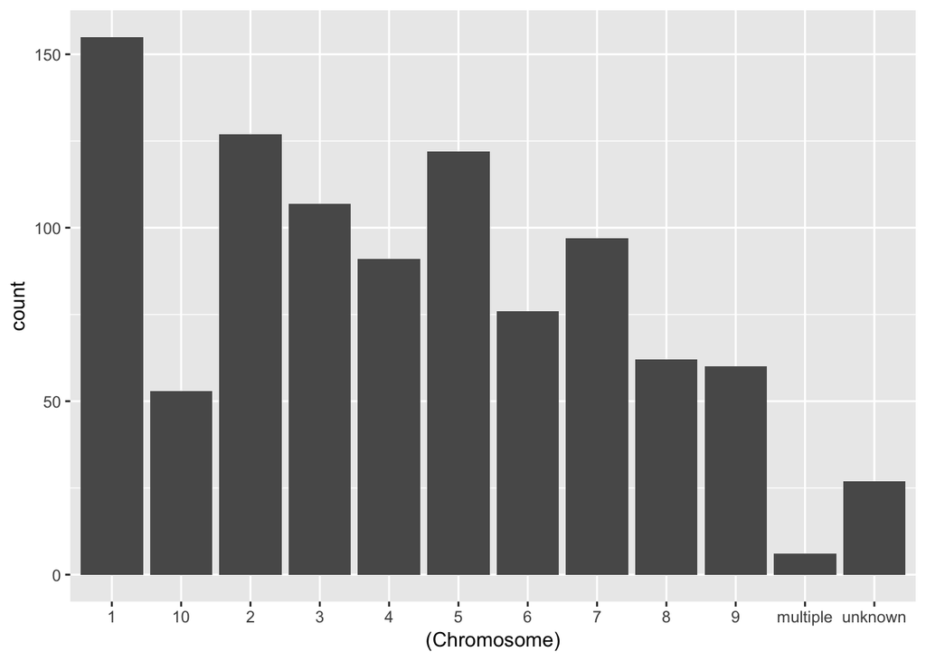

```r
fang_transposed <- as.data.frame(t(fang_et_al_genotypes[,-1]))
fang_transposed <- cbind(SNP_ID = row.names(fang_transposed), fang_transposed)
merge_fang <- merge(fang_transposed, snp_position, by = "SNP_ID")
merge_fang$Chromosome <- factor(merge_fang$Chromosome)
ggplot(merge_fang, aes((Chromosome))) + geom_bar()
```

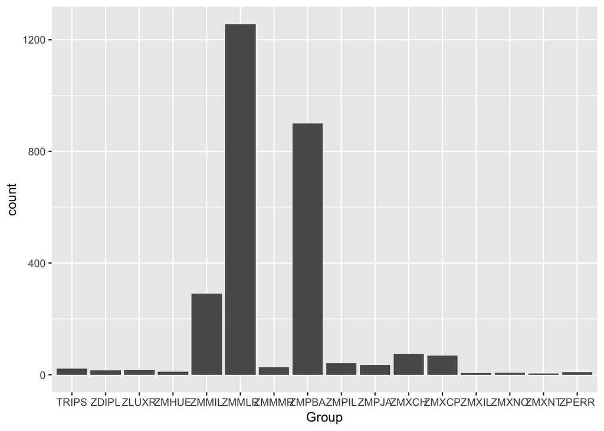

```r
ggplot(fang_et_al_genotypes, aes(Group)) + geom_bar()
```

To plot missing data and heterozygosity, we need to first process the files to show these data. We can create a new column that records whether the genotype characters match. In all of fang_et_al_genotypes, we can see a general proportion of homozygous to heterozygous to missing data.

```r
fang_melted <- melt(fang_et_al_genotypes, id = c("Sample_ID", "Group"))
```

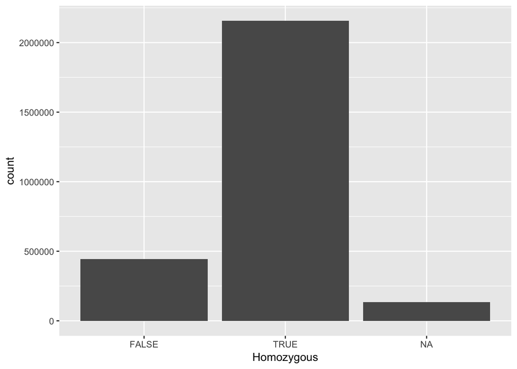

```r
fang_melted[fang_melted == "?/?" ] = NA
fang_melted$Homozygous <- (fang_melted$value=="A/A" | fang_melted$value=="C/C" | fang_melted$value=="G/G" | fang_melted$value=="T/T")
ggplot(fang_melted, aes(Homozygous)) + geom_bar()
```

To group this data by the species and group we will make some new intermediate data frames.

```r
fang_melted_group <- fang_melted[order(fang_melted$Group),]
fang_melted_ID <- fang_melted[order(fang_melted$Sample_ID),]
```

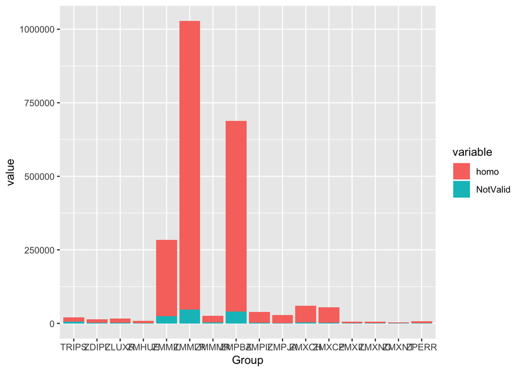

```r
fang_melted_group_prop <- ddply(fang_melted_group, c("Group"), summarise, homo=sum(Homozygous, na.rm=TRUE),
                     heter=sum(Homozygous, na.rm=FALSE), NotValid=sum(is.na(Homozygous)))
group_prop_melt <- melt(fang_melted_group_prop, measure.vars = c("homo", "heter", "NotValid"))

fang_melted_ID_prop <- ddply(fang_melted_ID, c("Sample_ID"), summarise, homo=sum(Homozygous, na.rm=TRUE),
                     heter=sum(Homozygous, na.rm=FALSE), NotValid=sum(is.na(Homozygous)))
ID_prop_melt <- melt(fang_melted_ID_prop, measure.vars = c("homo", "heter", "NotValid"))

ggplot(group_prop_melt,aes(x = Group, y= value, fill=variable)) + geom_bar(stat = "identity", position = "stack")
```

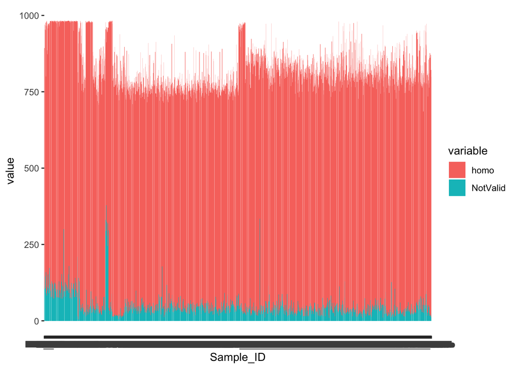

```r
ggplot(ID_prop_melt,aes(x = Sample_ID, y= value, fill=variable)) + geom_bar(stat = "identity", position = "stack")
```

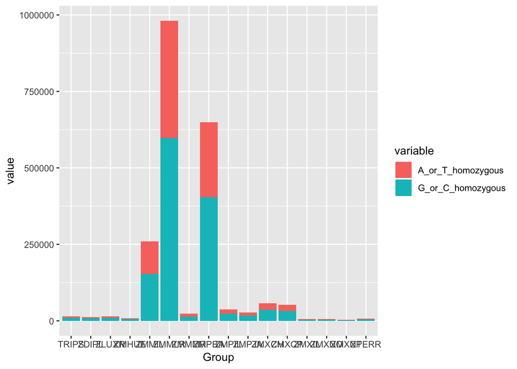

```r
fang_melted$AT <- (fang_melted$value=="A/A" | fang_melted$value=="T/T")
fang_melted$GC <- (fang_melted$value=="G/G" | fang_melted$value=="C/C")
fang_melted_group <- fang_melted[order(fang_melted$Group),]
fang_melted_AT_GC <- ddply(fang_melted_group, c("Group"), summarise, A_or_T_homozygous=sum(AT, na.rm=TRUE),
                     G_or_C_homozygous=sum(GC, na.rm=TRUE))
fang_melted_AT_GC_melt <- melt(fang_melted_AT_GC, measure.vars = c("A_or_T_homozygous", "G_or_C_homozygous"))
ggplot(fang_melted_AT_GC_melt,aes(x = Group, y= value, fill=variable)) + geom_bar(stat = "identity", position = "stack")
```